# skin cnacer classification using deep learning

### importing necessary libraries

numpy is good for numerical arrays

matplotlib will be required to render charts and plots of the data i will be using

tensorflow will be used for the machine learning model, but I will be using keras api as tensorflow is quite complex

```python
#imports
import numpy as np
import matplotlib.pyplot as plt
import os
from keras.layers import Dense, Dropout, Flatten
from tensorflow.keras.models import Sequential
from keras.models import Sequential
from keras.layers import Conv2D, MaxPooling2D
from tensorflow.keras import layers, losses
from tqdm import tqdm
from tensorflow.keras.preprocessing.image import ImageDataGenerator
from PIL import Image
from numpy import asarray
from sklearn.model_selection import KFold
from tensorflow.keras import optimizers
from keras import regularizers
from keras.regularizers import l2
from keras.regularizers import l1
```

image data generator will make working with the images easier

### Loading the data

the data is divided, the directories are already pre labeled into 9 different classes.

hence, the training and test data is labeled accordingly:

benign skin lesions:

- actinic keratosis
- pigmented benign keratosis
- dermatofibroma
- nevus
- sebhorrheic keratosis
- squamous cell carcinoma
- vascular lesion

malignant skin lesions:

- basal cell carcinoma
- melanoma

this will retrieve data from the correct path in the file

```python
PATH = '../Binary classification of skin cancer/data 9 class/'

train_file = os.path.join(PATH, 'Train')
test_file = os.path.join(PATH, 'Test')
```

##### training data

```python
train_actinic_file = os.path.join(train_file, 'actinic keratosis')
train_basal_file = os.path.join(train_file, 'basal cell carcinoma')
train_dermato_file = os.path.join(train_file, 'dermatofibroma')
train_melanoma_file = os.path.join(train_file, 'melanoma')
train_nevus_file = os.path.join(train_file, 'nevus')
train_pigment_file = os.path.join(train_file, 'pigmented benign keratosis')
train_seborr_file = os.path.join(train_file, 'seborrheic keratosis')
train_squamous_file = os.path.join(train_file, 'squamous cell carcinoma')
train_vascular_file = os.path.join(train_file, 'vascular lesion')
```

###### test data

```python
test_actinic_file = os.path.join(test_file, 'actinic keratosis')
test_basal_file = os.path.join(test_file, 'basal cell carcinoma')
test_dermato_file = os.path.join(test_file, 'dermatofibroma')
test_melanoma_file = os.path.join(test_file, 'melanoma')
test_nevus_file = os.path.join(test_file, 'nevus')
test_pigment_file = os.path.join(test_file, 'pigmented benign keratosis')
test_seborr_file = os.path.join(test_file, 'seborrheic keratosis')
test_squamous_file = os.path.join(test_file, 'squamous cell carcinoma')
test_vascular_file = os.path.join(test_file, 'vascular lesion')
```

ImageDataGenerator generates batches of tensor image data with real-time data augmentation

all the data will generalise into 224 by 224 image sizes

rescaling the images will squish the images to a value of 0 to 1

```python
# Training subset of dataset, rescaled to binary scale, 8:2 split Training:validation, applied
train_img_gen = ImageDataGenerator(
    rescale=1./255,
    validation_split=0.2,
)

test_img_gen = ImageDataGenerator(rescale=1./255)
val_data_gen = ImageDataGenerator(rescale=1./255)



train_data_generator = train_img_gen.flow_from_directory(batch_size=128,
                                                           directory=train_file,
                                                           shuffle=True,
                                                           target_size=(224, 224),
                                                           class_mode='categorical')

test_data_generator = test_img_gen.flow_from_directory(batch_size=128,
                                                         directory=test_file,
                                                         target_size=(224, 224),
                                                         class_mode='categorical')

validation_generator = train_img_gen.flow_from_directory(directory=train_file,
                                                         batch_size=128,
                                                          shuffle=False,

                                                          target_size=(224, 224),
                                                        class_mode='categorical',
                                                         subset='validation'
                                                        )
```

```
Found 2239 images belonging to 9 classes.
Found 118 images belonging to 9 classes.
Found 444 images belonging to 9 classes.
```

```python
total_train_size = len(os.listdir(train_actinic_file)) + len(os.listdir(train_basal_file)) + len(os.listdir(train_dermato_file)) + len(os.listdir(train_melanoma_file)) + len(os.listdir(train_nevus_file)) + len(os.listdir(train_pigment_file)) + len(os.listdir(train_seborr_file)) + len(os.listdir(train_squamous_file)) + len(os.listdir(train_vascular_file))

total_test_size = len(os.listdir(test_actinic_file)) + len(os.listdir(test_basal_file)) + len(os.listdir(test_dermato_file)) + len(os.listdir(test_melanoma_file)) +len(os.listdir(test_nevus_file)) + len(os.listdir(test_pigment_file)) + len(os.listdir(test_seborr_file)) + len(os.listdir(test_squamous_file)) + len(os.listdir(test_vascular_file))

print(total_train_size, " - training images in total")
print(total_test_size, " - test images in total")
```

```
2239  - training images in total
118  - test images in total
```

### Data visualisation

```python
train_data_generator.image_shape
```

```
(224, 224, 3)
```

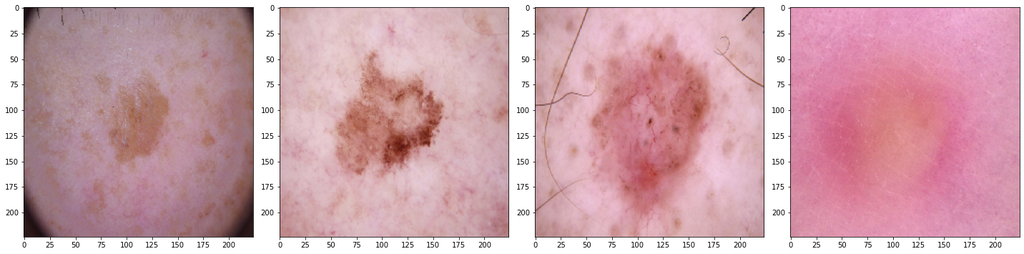

```python
def samples(array_image):
    fig, axes = plt.subplots(1, 4, figsize=(20, 20))
    ax = axes.flatten()
    for img, ax in zip(array_image, axes):
        ax.imshow(img)

    plt.tight_layout()
    plt.show()

test_img, labels_ = next(test_data_generator)

samples(test_img[:10])
```

##### Display random images with one-hot encoded labels

[103]deeplizard, “Mapping Keras labels to image classes,” deeplizard.com, Dec. 21, 2017. [Online]. Available: https://deeplizard.com/learn/video/pZoy_j3YsQg. [Accessed: Apr. 28, 2022]

```python
def one_hot(image, figsize=(15,15), rows=2, interp=False, titles=None):
    if type(image[0]) is np.ndarray:
        ims = np.array(image).astype(np.uint8)
        if (image.shape[-1] != 3):
            image = image.transpose((0,2,3,1))
    f = plt.figure(figsize=figsize)
    cols = len(image)//rows if len(image) % 2 == 0 else len(image)//rows + 1
    for i in range(len(image)):
        sp = f.add_subplot(rows, cols, i+1)
        sp.axis('Off')
        if titles is not None:
            sp.set_title(titles[i], fontsize=20)
        plt.imshow(image[i], interpolation=None if interp else 'none')
```

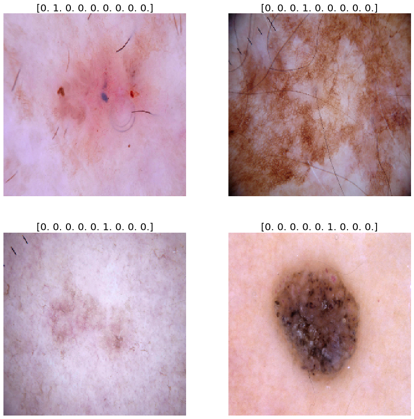

```python
train_imgs, labels = next(train_data_generator)
one_hot(train_imgs[:4], titles=labels)
```

[1.0.0.0.0.0.0.0.0] = actinic keratosis  
[0.1.0.0.0.0.0.0.0] = basal cell carcinoma  
[0.0.1.0.0.0.0.0.0] = dermatofibroma  
[0.0.0.1.0.0.0.0.0] = melanoma  
[0.0.0.0.1.0.0.0.0] = nevus  
[0.0.0.0.0.1.0.0.0] = pigmented benign keratosis  
[0.0.0.0.0.0.1.0.0] = seborrheic keratosis  
[0.0.0.0.0.0.0.1.0] = squamous cell carcinoma  
[0.0.0.0.0.0.0.0.1] = vascular lesion

## model with stat power

The following model conisists of only 1 convolutional layer, followed by maxpooling, flatten and dense layer, with a softmax output layer.

This filter size is kept relitively small, as it is justtring to beat the commonsense baseline of the model (0.11)

```python
model = Sequential([

    layers.Conv2D(8, 3, activation='relu' ,input_shape=(224,224,3)),
    layers.MaxPooling2D(pool_size=(2,2)),
    layers.Flatten(),
    layers.Dense(32, activation='relu'),
    layers.Dense(9, activation='softmax')
])
```

```python
model.summary()
```

```
Model: "sequential_2"
_________________________________________________________________
 Layer (type)                Output Shape              Param #
=================================================================
 conv2d_5 (Conv2D)           (None, 222, 222, 8)       224

 max_pooling2d_5 (MaxPooling  (None, 111, 111, 8)      0
 2D)

 flatten_2 (Flatten)         (None, 98568)             0

 dense_4 (Dense)             (None, 32)                3154208

 dense_5 (Dense)             (None, 9)                 297

=================================================================
Total params: 3,154,729
Trainable params: 3,154,729
Non-trainable params: 0
_________________________________________________________________
```

```python
 model.compile(optimizer="rmsprop", loss='categorical_crossentropy', metrics=['accuracy'])
```

```python
history = model.fit(
        train_data_generator,
        batch_size =128,
        epochs=10,
#         steps_per_epoch=50,
        validation_data=validation_generator,
#         validation_steps=250,
#         callbacks=[save]
    )
```

### Plotting results

```python
history_dict = history.history
history_dict.keys()
history_dict['loss']
history_dict['val_loss']
history_dict['accuracy']
history_dict['val_accuracy']
```

```
[0.14639639854431152,
 0.29279279708862305,
 0.29279279708862305,
 0.3355855941772461,
 0.29729729890823364,
 0.2409909963607788,
 0.4301801919937134,
 0.5090090036392212,
 0.3536036014556885,
 0.5743243098258972]
```

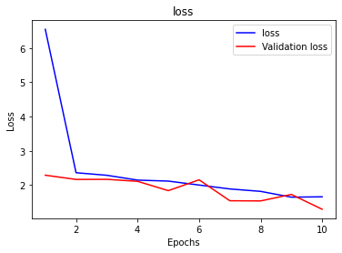

```python
loss = history_dict['loss']
val_loss = history_dict['val_loss']
epochs = range(1, len(loss) + 1)
blue_l = 'b'
red_l = 'r'
plt.plot(epochs, loss, blue_l, label = 'loss')
plt.plot(epochs, val_loss, red_l, label = 'Validation loss')
plt.title('loss')
plt.xlabel('Epochs')
plt.ylabel('Loss')
plt.legend()

plt.show()
```

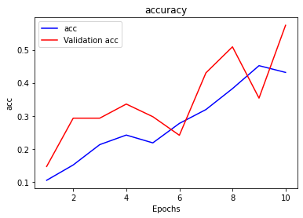

```python
loss = history_dict['accuracy']
val_loss = history_dict['val_accuracy']
epochs = range(1, len(loss) + 1)
blue_l = 'b'
red_l = 'r'
plt.plot(epochs, loss, blue_l, label = 'acc')
plt.plot(epochs, val_loss, red_l, label = 'Validation acc')
plt.title('accuracy')
plt.xlabel('Epochs')
plt.ylabel('acc')
plt.legend()

plt.show()
```

## dropout

```python
model = Sequential([

    layers.Conv2D(32, 3, activation='relu' ,input_shape=(224,224,3)),
    layers.Dropout(0.5),
    layers.MaxPooling2D(pool_size=(2,2)),
    layers.Conv2D(64, 3, activation='relu'),
    layers.MaxPooling2D(pool_size=(2,2)),
    layers.Flatten(),
    layers.Dense(64, activation='relu'),
    layers.Dense(9, activation='softmax')
])
```

```python
model.summary()
```

```
Model: "sequential_2"
_________________________________________________________________
 Layer (type)                Output Shape              Param #
=================================================================
 conv2d_4 (Conv2D)           (None, 222, 222, 32)      896

 dropout (Dropout)           (None, 222, 222, 32)      0

 max_pooling2d_4 (MaxPooling  (None, 111, 111, 32)     0
 2D)

 conv2d_5 (Conv2D)           (None, 109, 109, 64)      18496

 max_pooling2d_5 (MaxPooling  (None, 54, 54, 64)       0
 2D)

 flatten_2 (Flatten)         (None, 186624)            0

 dense_4 (Dense)             (None, 64)                11944000

 dense_5 (Dense)             (None, 9)                 585

=================================================================
Total params: 11,963,977
Trainable params: 11,963,977
Non-trainable params: 0
_________________________________________________________________
```

```python
 model.compile(optimizer="rmsprop", loss='categorical_crossentropy', metrics=['accuracy'])
```

```python
history = model.fit(
        train_data_generator,
        batch_size =128,
        epochs=20,
        validation_data=validation_generator,
    )
```

```python
history_dict = history.history
history_dict.keys()
history_dict['loss']
history_dict['val_loss']
history_dict['accuracy']
history_dict['val_accuracy']
```

[output not shown]

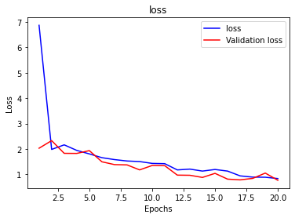

```python
loss = history_dict['loss']
val_loss = history_dict['val_loss']
epochs = range(1, len(loss) + 1)
blue_l = 'b'
red_l = 'r'
plt.plot(epochs, loss, blue_l, label = 'loss')
plt.plot(epochs, val_loss, red_l, label = 'Validation loss')
plt.title('loss')
plt.xlabel('Epochs')
plt.ylabel('Loss')
plt.legend()

plt.show()
```

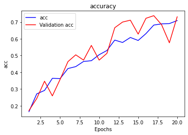

```python
loss = history_dict['accuracy']
val_loss = history_dict['val_accuracy']
epochs = range(1, len(loss) + 1)
blue_l = 'b'
red_l = 'r'
plt.plot(epochs, loss, blue_l, label = 'acc')
plt.plot(epochs, val_loss, red_l, label = 'Validation acc')
plt.title('accuracy')
plt.xlabel('Epochs')
plt.ylabel('acc')
plt.legend()

plt.show()
```

# =================================

```python
model = Sequential([

    layers.Conv2D(32, 3, activation='relu' ,input_shape=(224,224,3)),
    layers.Dropout(0.3),
    layers.MaxPooling2D(pool_size=(2,2)),
    layers.Conv2D(64, 3, activation='relu'),
    layers.MaxPooling2D(pool_size=(2,2)),
    layers.Flatten(),
    layers.Dense(64, activation='relu'),
    layers.Dense(9, activation='softmax')
])
```

```python
 model.compile(optimizer="Adam", loss='categorical_crossentropy', metrics=['accuracy'])
```

```python
model.summary()
```

```
Model: "sequential_6"
_________________________________________________________________
 Layer (type)                Output Shape              Param #
=================================================================
 conv2d_12 (Conv2D)          (None, 222, 222, 32)      896

 dropout_4 (Dropout)         (None, 222, 222, 32)      0

 max_pooling2d_12 (MaxPoolin  (None, 111, 111, 32)     0
 g2D)

 conv2d_13 (Conv2D)          (None, 109, 109, 64)      18496

 max_pooling2d_13 (MaxPoolin  (None, 54, 54, 64)       0
 g2D)

 flatten_6 (Flatten)         (None, 186624)            0

 dense_12 (Dense)            (None, 64)                11944000

 dense_13 (Dense)            (None, 9)                 585

=================================================================
Total params: 11,963,977
Trainable params: 11,963,977
Non-trainable params: 0
_________________________________________________________________
```

```python
history = model.fit(
        train_data_generator,
        batch_size =128,
        epochs=20,
        validation_data=validation_generator,
    )
```

```python
history_dict = history.history
history_dict.keys()
history_dict['loss']
history_dict['val_loss']
history_dict['accuracy']
history_dict['val_accuracy']
```

```
[0.3536036014556885,
 0.4887387454509735,
 0.5360360145568848,
 0.5382882952690125,
 0.6261261105537415,
 0.6779279112815857,
 0.6734234094619751,
 0.6756756901741028,
 0.7837837934494019,
 0.8108108043670654,
 0.8445945978164673,
 0.8288288116455078,
 0.8603603839874268,
 0.8603603839874268,
 0.9144144058227539,
 0.8783783912658691,
 0.8918918967247009,
 0.9009009003639221,
 0.9076576828956604,
 0.9189189076423645]
```

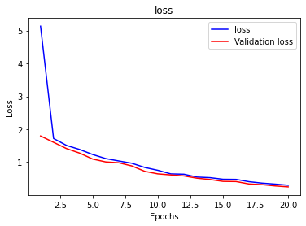

```python
loss = history_dict['loss']
val_loss = history_dict['val_loss']
epochs = range(1, len(loss) + 1)
blue_l = 'b'
red_l = 'r'
plt.plot(epochs, loss, blue_l, label = 'loss')
plt.plot(epochs, val_loss, red_l, label = 'Validation loss')
plt.title('loss')
plt.xlabel('Epochs')
plt.ylabel('Loss')
plt.legend()

plt.show()
```

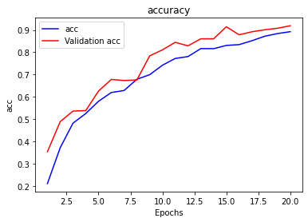

```python
loss = history_dict['accuracy']
val_loss = history_dict['val_accuracy']
epochs = range(1, len(loss) + 1)
blue_l = 'b'
red_l = 'r'
plt.plot(epochs, loss, blue_l, label = 'acc')
plt.plot(epochs, val_loss, red_l, label = 'Validation acc')
plt.title('accuracy')
plt.xlabel('Epochs')
plt.ylabel('acc')
plt.legend()

plt.show()
```

## optimal Model (FInal model)

```python
model = Sequential([
# use drop out on first layer of relu

    layers.Conv2D(32, 3, activation='relu' ,input_shape=(224,224,3)),
    layers.Dropout(0.3),
    layers.MaxPooling2D(pool_size=(2,2)),
    layers.Conv2D(64, 3, activation='relu'),
    layers.MaxPooling2D(pool_size=(2,2)),
    layers.Flatten(),
    layers.Dense(128, activation='relu'),
    layers.Dense(9, activation='softmax')
])
```

```python
model.summary()
```

```
Model: "sequential_7"
_________________________________________________________________
 Layer (type)                Output Shape              Param #
=================================================================
 conv2d_14 (Conv2D)          (None, 222, 222, 32)      896

 dropout_5 (Dropout)         (None, 222, 222, 32)      0

 max_pooling2d_14 (MaxPoolin  (None, 111, 111, 32)     0
 g2D)

 conv2d_15 (Conv2D)          (None, 109, 109, 64)      18496

 max_pooling2d_15 (MaxPoolin  (None, 54, 54, 64)       0
 g2D)

 flatten_7 (Flatten)         (None, 186624)            0

 dense_14 (Dense)            (None, 128)               23888000

 dense_15 (Dense)            (None, 9)                 1161

=================================================================
Total params: 23,908,553
Trainable params: 23,908,553
Non-trainable params: 0
_________________________________________________________________
```

```python
 model.compile(optimizer="Adam", loss='categorical_crossentropy', metrics=['accuracy'])
```

```python
history = model.fit(
        train_data_generator,
        batch_size =128,
        epochs=20,
        validation_data=validation_generator,
    )
model.save('exp_32.h5')
```

```python
history_dict = history.history
history_dict.keys()
history_dict['loss']
history_dict['val_loss']
history_dict['accuracy']
history_dict['val_accuracy']
```

```
[0.3558558523654938,
 0.4031531512737274,
 0.46621620655059814,
 0.5495495200157166,
 0.5675675868988037,
 0.6216216087341309,
 0.6013513803482056,
 0.662162184715271,
 0.6418918967247009,
 0.7342342138290405,
 0.704954981803894,
 0.7432432174682617,
 0.8175675868988037,
 0.837837815284729,
 0.815315306186676,
 0.8536036014556885,
 0.8896396160125732,
 0.869369387626648,
 0.9234234094619751,
 0.9009009003639221]
```

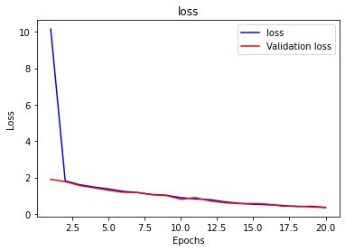

```python
loss = history_dict['loss']
val_loss = history_dict['val_loss']
epochs = range(1, len(loss) + 1)
blue_l = 'b'
red_l = 'r'
plt.plot(epochs, loss, blue_l, label = 'loss')
plt.plot(epochs, val_loss, red_l, label = 'Validation loss')
plt.title('loss')
plt.xlabel('Epochs')
plt.ylabel('Loss')
plt.legend()

plt.show()
```

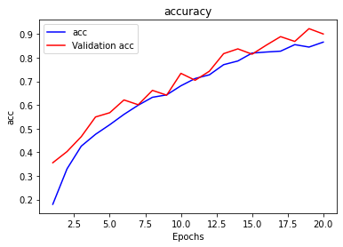

```python
loss = history_dict['accuracy']
val_loss = history_dict['val_accuracy']
epochs = range(1, len(loss) + 1)
blue_l = 'b'
red_l = 'r'
plt.plot(epochs, loss, blue_l, label = 'acc')
plt.plot(epochs, val_loss, red_l, label = 'Validation acc')
plt.title('accuracy')
plt.xlabel('Epochs')
plt.ylabel('acc')
plt.legend()

plt.show()
```

```python
from keras.models import load_model
model_x = load_model('exp_32.h5')

history = model_x.fit(
        test_data_generator,
        epochs=20,
    )
```

```python
history_dict = history.history
history_dict.keys()
history_dict['loss']
history_dict['accuracy']
```

```
[0.27966102957725525,
 0.37288135290145874,
 0.33898305892944336,
 0.33898305892944336,
 0.44915252923965454,
 0.4406779706478119,
 0.4237288236618042,
 0.5593220591545105,
 0.5338982939720154,
 0.4830508530139923,
 0.508474588394165,
 0.6101694703102112,
 0.6610169410705566,
 0.6694915294647217,
 0.694915235042572,
 0.7203390002250671,
 0.7118644118309021,
 0.7542372941970825,
 0.7457627058029175,
 0.7372881174087524]
```

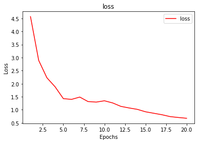

```python
loss = history_dict['loss']
epochs = range(1, len(loss) + 1)
red_l = 'r'
plt.plot(epochs,
         loss,
         red_l,
         label = 'loss')
plt.title('loss')
plt.xlabel('Epochs')
plt.ylabel('Loss')
plt.legend()

plt.show()
```

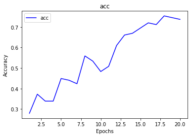

```python
acc = history_dict['accuracy']
epochs = range(1, len(acc) + 1)
blue_l = 'b'
plt.plot(epochs, acc, blue_l, label = 'acc')
plt.title('acc')
plt.xlabel('Epochs')
plt.ylabel('Accuracy')
plt.legend()
plt.show()
```

## Experimentation data log

### Model that beats the baseline

| no. | Number of epochs | Validation accuracy | Validation loss | conv layers | filters | dense layer | layer depth | optimiser | overfitting |
| --- | --- | --- | --- | --- | --- | --- | --- | --- | --- |
| 1 | 10 | 0.4910 | 1.5008 | 1 | 1 | - | 4 | rmsprop = 0.001 | 2 |

### Model with enough power to overfit

| no. | Number of epochs | Validation accuracy | Validation loss | conv layers | filters | dense layer | layer depth | optimiser | overfitting |
| --- | --- | --- | --- | --- | --- | --- | --- | --- | --- |
| 1 | 20 | 0.8536 | 0.4526 | 2 | 32-64 | 1 = 64 | 7 | rmsprop = 0.001 | 6 |

### filter size

| no. | Number of epochs | Validation accuracy | Validation loss | conv layers | filters | dense layer | layer depth | optimiser | overfitting |
| --- | --- | --- | --- | --- | --- | --- | --- | --- | --- |
| 3 | 20 | 0.8356 | 0.4379 | 2 | 64-128 | 1 = 64 | 7 | rmsprop = 0.001 | 2.5 |

| no. | Number of epochs | Validation accuracy | Validation loss | conv layers | filters | dense layer | layer depth | optimiser | overfitting |
| --- | --- | --- | --- | --- | --- | --- | --- | --- | --- |
| 4 | 20 | 0.7883 | 0.6468 | 2 | 16-32 | 1 = 64 | 7 | rmsprop = 0.001 | 6 |

| no. | Number of epochs | Validation accuracy | Validation loss | conv layers | filters | dense layer | layer depth | optimiser | overfitting |
| --- | --- | --- | --- | --- | --- | --- | --- | --- | --- |
| 5 | 20 | 0.6622 | 0.8731 | 2 | 8-16 | 1 = 64 | 7 | rmsprop = 0.001 | 2.5 |

### Layer depth

| no. | Number of epochs | Validation accuracy | Validation loss | conv layers | filters | dense layer | layer depth | optimiser | overfitting |
| --- | --- | --- | --- | --- | --- | --- | --- | --- | --- |
| 3 | 20 | 0.8356 | 0.4379 | 2 | 64-128 | 1 = 64 | 7 | rmsprop = 0.001 | 2.5 |

| no. | Number of epochs | Validation accuracy | Validation loss | conv layers | filters | dense layer | layer depth | optimiser | overfitting |
| --- | --- | --- | --- | --- | --- | --- | --- | --- | --- |
| 6 | 20 | 0.5878 | 1.1504 | 3 | 32-64-64 | 1 = 64 | 9 | rmsprop = 0.001 | 10 |

| no. | Number of epochs | Validation accuracy | Validation loss | conv layers | filters | dense layer | layer depth | optimiser | overfitting |
| --- | --- | --- | --- | --- | --- | --- | --- | --- | --- |
| 7 | 20 | 0.6126 | 1.0719 | 3 | 32-64-128 | 1 = 64 | 9 | rmsprop = 0.001 | 6 |

| no. | Number of epochs | Validation accuracy | Validation loss | conv layers | filters | dense layer | layer depth | optimiser | overfitting |
| --- | --- | --- | --- | --- | --- | --- | --- | --- | --- |
| 8 | 20 | 0.4414 | 1.5218 | 6 | 32-32-64-64-128-128 | 1 = 64 | 15 | rmsprop = 0.001 | 7 |

| no. | Number of epochs | Validation accuracy | Validation loss | conv layers | filters | dense layer | layer depth | optimiser | overfitting |
| --- | --- | --- | --- | --- | --- | --- | --- | --- | --- |
| 9 | 20 | 0.7342 | 0.8404 | 6 | 16-32-64 | 1 = 64 | 9 | rmsprop = 0.001 | 9 |

| no. | Number of epochs | Validation accuracy | Validation loss | conv layers | filters | dense layer | layer depth | optimiser | overfitting |
| --- | --- | --- | --- | --- | --- | --- | --- | --- | --- |
| 10 | 20 | 0.7140 | 0.7927 | 4 | 32-32-64-64 | 1 = 64 | 9 | rmsprop = 0.001 | 9 |

### Optimiser experiments

| no. | Number of epochs | Validation accuracy | Validation loss | conv layers | filters | dense layer | layer depth | optimiser | overfitting |
| --- | --- | --- | --- | --- | --- | --- | --- | --- | --- |
| 11 | 20 | 0.7973 | 0.5594 | 2 | 32-64 | 1 = 64 | 7 | adam = 0.001 | 7 |

| no. | Number of epochs | Validation accuracy | Validation loss | conv layers | filters | dense layer | layer depth | optimiser | overfitting |
| --- | --- | --- | --- | --- | --- | --- | --- | --- | --- |
| 12 | 20 | 0.8153 | 0.5352 | 2 | 32-64 | 1 = 64 | 7 | adam = 0.001 | 7 |

| no. | Number of epochs | Validation accuracy | Validation loss | conv layers | filters | dense layer | layer depth | optimiser | overfitting |
| --- | --- | --- | --- | --- | --- | --- | --- | --- | --- |
| 13 | 20 | 0.7703 | 0.6860 | 2 | 32-64 | 1 = 64 | 7 | rmsprop = 0.001 | 7 |

| no. | Number of epochs | Validation accuracy | Validation loss | conv layers | filters | dense layer | layer depth | optimiser | overfitting |
| --- | --- | --- | --- | --- | --- | --- | --- | --- | --- |
| 14 | 35 | 0.9505 | 0.1688 | 2 | 32-64 | 1 = 64 | 7 | adam = 0.001 | 7 |

| no. | Number of epochs | Validation accuracy | Validation loss | conv layers | filters | dense layer | layer depth | optimiser | overfitting |
| --- | --- | --- | --- | --- | --- | --- | --- | --- | --- |
| 15 | 35 | 0.9122 | 0.2957 | 2 | 32-64 | 1 = 64 | 7 | rmsprop = 0.001 | 7 |

### dropout experiments

| no. | Number of epochs | Validation accuracy | Validation loss | conv layers | filters | dense layer | layer depth | optimiser | overfitting | dropout |
| --- | --- | --- | --- | --- | --- | --- | --- | --- | --- | --- |
| 16 | 20 | 0.8018 | 0.7079 | 2 | 32-64 | 1 = 64 | 8 | adam = 0.001 | 7 | 0.5 |

| no. | Number of epochs | Validation accuracy | Validation loss | conv layers | filters | dense layer | layer depth | optimiser | overfitting | dropout |
| --- | --- | --- | --- | --- | --- | --- | --- | --- | --- | --- |
| 17 | 20 | 0.8243 | 0.5653 | 2 | 32-64 | 1 = 64 | 8 | adam = 0.001 | 7 | 0.3 |

| no. | Number of epochs | Validation accuracy | Validation loss | conv layers | filters | dense layer | layer depth | optimiser | overfitting | dropout |
| --- | --- | --- | --- | --- | --- | --- | --- | --- | --- | --- |
| 18 | 20 | 0.5833 | 1.4379 | 2 | 32-64 | 1 = 64 | 8 | adam = 0.001 | 7 | 0.7 |

| no. | Number of epochs | Validation accuracy | Validation loss | conv layers | filters | dense layer | layer depth | optimiser | overfitting | dropout |
| --- | --- | --- | --- | --- | --- | --- | --- | --- | --- | --- |
| 19 | 20 | 0.8041 | 0.6143 | 2 | 32-64 | 1 = 64 | 8 | adam = 0.001 | 7 | 0.2 |

| no. | Number of epochs | Validation accuracy | Validation loss | conv layers | filters | dense layer | layer depth | optimiser | overfitting | dropout |
| --- | --- | --- | --- | --- | --- | --- | --- | --- | --- | --- |
| 20 | 20 | 0.5495 | 1.1898 | 2 | 32-64 | 1 = 64 | 8 | adam = 0.001 | 7 | 0.2-0.2 |

### Learning rate

| no. | Number of epochs | Validation accuracy | Validation loss | conv layers | filters | dense layer | layer depth | optimiser | overfitting | dropout |
| --- | --- | --- | --- | --- | --- | --- | --- | --- | --- | --- |
| 21 | 20 | 0.2072 | 2.0115 | 2 | 32-64 | 1 = 64 | 8 | adam = 0.01 | 8 | 0.3 |

| no. | Number of epochs | Validation accuracy | Validation loss | conv layers | filters | dense layer | layer depth | optimiser | overfitting | dropout |
| --- | --- | --- | --- | --- | --- | --- | --- | --- | --- | --- |
| 22 | 20 | 0.5450 | 1.2958 | 2 | 32-64 | 1 = 64 | 8 | adam = 0.0001 | 8 | 0.3 |

### Weight regularisers

##### L1

| no. | Number of epochs | Validation accuracy | Validation loss | conv layers | filters | dense layer | layer depth | optimiser | overfitting | dropout | L1 regulariser |
| --- | --- | --- | --- | --- | --- | --- | --- | --- | --- | --- | --- |
| 23 | 20 | 0.6126 | 2.2536 | 2 | 32-64 | 1 = 64 | 8 | adam = 0.001 |  | 0.3 | 0.01 |

| no. | Number of epochs | Validation accuracy | Validation loss | conv layers | filters | dense layer | layer depth | optimiser | overfitting | dropout | L1 regulariser |
| --- | --- | --- | --- | --- | --- | --- | --- | --- | --- | --- | --- |
| 24 | 20 | 0.6577 | 1.2759 | 2 | 32-64 | 1 = 64 | 8 | adam = 0.001 |  | 0.3 | 0.001 |

| no. | Number of epochs | Validation accuracy | Validation loss | conv layers | filters | dense layer | layer depth | optimiser | overfitting | dropout | L1 regulariser |
| --- | --- | --- | --- | --- | --- | --- | --- | --- | --- | --- | --- |
| 25 | 20 | 0.5338 | 2.3169 | 2 | 32-64 | 1 = 64 | 8 | adam = 0.001 |  | 0.3 | 0.005 |

##### L2

| no. | Number of epochs | Validation accuracy | Validation loss | conv layers | filters | dense layer | layer depth | optimiser | overfitting | dropout | L2 regulariser |
| --- | --- | --- | --- | --- | --- | --- | --- | --- | --- | --- | --- |
| 26 | 20 | 0.8041 | 0.7098 | 2 | 32-64 | 1 = 64 | 8 | adam = 0.001 |  | 0.3 | 0.001 |

| no. | Number of epochs | Validation accuracy | Validation loss | conv layers | filters | dense layer | layer depth | optimiser | overfitting | dropout | L2 regulariser |
| --- | --- | --- | --- | --- | --- | --- | --- | --- | --- | --- | --- |
| 27 | 20 | 0.7568 | 0.9369 | 2 | 32-64 | 1 = 64 | 8 | adam = 0.001 |  | 0.3 | 0.01 |

| no. | Number of epochs | Validation accuracy | Validation loss | conv layers | filters | dense layer | layer depth | optimiser | overfitting | dropout | L2 regulariser |
| --- | --- | --- | --- | --- | --- | --- | --- | --- | --- | --- | --- |
| 28 | 20 | 0.6757 | 1.0647 | 2 | 32-64 | 1 = 64 | 8 | adam = 0.001 |  | 0.3 | 0.005 |

### Extra exp

| no. | Number of epochs | Validation accuracy | Validation loss | conv layers | filters | dense layer | layer depth | optimiser | overfitting | dropout |
| --- | --- | --- | --- | --- | --- | --- | --- | --- | --- | --- |
| 29 | 20 | 0.9032 | 0.3029 | 2 | 32-64 | 1 = 128 | 8 | adam = 0.001 |  | 0.3 |

=================================================================================

| no. | Number of epochs | Validation accuracy | Validation loss | filter 1 | filter 2 | dense layer | conv layers | learning rate | data aug | layer depth |
| --- | --- | --- | --- | --- | --- | --- | --- | --- | --- | --- |
| 1 | 45 | 0.538 | 1.279 | 16 | 32 | 32 | 3 | 0.001 | Y | 9 |

| no. | Number of epochs | Validation accuracy | Validation loss | filter 1 | filter 2 | dense layer | conv layers | learning rate | data aug | layer depth |
| --- | --- | --- | --- | --- | --- | --- | --- | --- | --- | --- |
| 2 | 50 | 0.4234 | 1.5558 | 32 | 16 | 8 | 3 | 0.001 | Y | 9 |

| no. | Number of epochs | Validation accuracy | Validation loss | filter 1 | filter 2 | dense layer | conv layers | learning rate | data aug | layer depth |
| --- | --- | --- | --- | --- | --- | --- | --- | --- | --- | --- |
| 3 | 50 | 0.3401 | 1.7782 | 8 | 4 | 2 | 3 | 0.001 | Y | 9 |

| no. | Number of epochs | Validation accuracy | Validation loss | filter 1 | filter 2 | dense layer | conv layers | learning rate | data aug | layer depth |
| --- | --- | --- | --- | --- | --- | --- | --- | --- | --- | --- |
| 4 | 50 | 0.4752 | 1.5264 | 32 | 64 | 64 | 2 | 0.001 | Y | 7 |

| no. | Number of epochs | Validation accuracy | Validation loss | filter 1 | filter 2 | dense layer | conv layers | learning rate | data aug | overfitting | layer depth |
| --- | --- | --- | --- | --- | --- | --- | --- | --- | --- | --- | --- |
| 5 | 100 | 0.9774 | 0.07 | 32 | 64 | 64 | 2 | 0.001 | N | 2-3 epoch | 7 |

| no. | Number of epochs | Validation accuracy | Validation loss | filter 1 | filter 2 | dense layer | conv layers | learning rate | data aug | overfitting | layer depth |
| --- | --- | --- | --- | --- | --- | --- | --- | --- | --- | --- | --- |
| 6 | 50 | 0.9550 | 0.1770 | 64 | 32 | 32 | 2 | 0.001 | N | 15 epoch | 7 |

baseline model

| no. | Number of epochs | Validation accuracy | Validation loss | filter 1 | filter 2 | filter 3 | dense layer | conv layers | learning rate | data aug | overfitting | layer depth |
| --- | --- | --- | --- | --- | --- | --- | --- | --- | --- | --- | --- | --- |
| 7 | 20 | 0.5766 | 1.1640 | 8 | 16 | 32 | 128 | 4 | 0.001 | N | 2.8-3 | 11 |

model with stat power

| no. | Number of epochs | Validation accuracy | Validation loss | filter 1 | filter 2 | filter 3 | dense layer | conv layers | learning rate | data aug | overfitting | layer depth |
| --- | --- | --- | --- | --- | --- | --- | --- | --- | --- | --- | --- | --- |
| 8 | 20 | 0.5158 | 1.2612 | 32 | 64 | 128 | 512 | 4 | 0.001 | N | after 5 | 11 |

| no. | Number of epochs | Validation accuracy | Validation loss | filter 1 | filter 2 | filter 3 | dense layer | conv layers | learning rate | data aug | overfitting | layer depth |
| --- | --- | --- | --- | --- | --- | --- | --- | --- | --- | --- | --- | --- |
| 9 | 20 | 0.9234 | 0.3 | 32 | 64 | 128 | 512 | 3 | 0.001 | N | x | 9 |

| no. | Number of epochs | Validation accuracy | Validation loss | filter 1 | filter 2 | filter 3 | dense layer | conv layers | learning rate | data aug | overfitting | layer depth |
| --- | --- | --- | --- | --- | --- | --- | --- | --- | --- | --- | --- | --- |
| 10 | 20 | 0.5631 | 1.3032 | 32 | 64 | 128 | 512 | 5 | 0.001 | N | 2.5 | 13 |

| no. | Number of epochs | Validation accuracy | Validation loss | filter 1 | filter 2 | filter 3 | dense layer | conv layers | learning rate | data aug | overfitting | layer depth |
| --- | --- | --- | --- | --- | --- | --- | --- | --- | --- | --- | --- | --- |
| 11 | 20 | 0.4977 | 1.4034 | 32 | 64 | 128 | 128 | 5 | 0.001 | N | 4 | 13 |

| no. | Number of epochs | Validation accuracy | Validation loss | filter 1 | filter 2 | filter 3 | dense layer | conv layers | learning rate | data aug | overfitting | layer depth | drop out |
| --- | --- | --- | --- | --- | --- | --- | --- | --- | --- | --- | --- | --- | --- |
| 12 | 20 | 0.6374 | 1.1711 | 32 | 64 | 128 | 128 | 5 | 0.001 | N | 4 | 13 | 0.5 |

| no. | Number of epochs | Validation accuracy | Validation loss | filter 1 | filter 2 | filter 3 | dense layer | conv layers | learning rate | data aug | overfitting | layer depth |
| --- | --- | --- | --- | --- | --- | --- | --- | --- | --- | --- | --- | --- |
| 13 | 20 | 0.8829 | 0.3873 | 32 | - | - | 64 | 1 | 0.001 | N | 4 | 5 |

| no. | Number of epochs | Validation accuracy | Validation loss | filter 1 | filter 2 | filter 3 | dense layer | conv layers | learning rate | data aug | overfitting | layer depth |
| --- | --- | --- | --- | --- | --- | --- | --- | --- | --- | --- | --- | --- |
| 14 | 20 | 0.6892 | 0.7693 | 32 | - | - | 64 | 3 | 0.001 | N | - | 9 |

```python
%history
```

[output not shown]

[output cut: 4574 more lines]

[output not shown]